# Лабораторная работа №4

Операционные системы

Репкина Е. А.

Российский университет дружбы народов, Москва, Россия

4 марта 2025

## Докладчик

- Репкина Елизавета Андреевна
- НКАбд-04-24
- Российский университет дружбы народов
- https://github.com/lizeeew

## Цель работы

Получение навыков правильной работы с репозиториями git.

## Задание

```
-Выполнить работу для тестового репозитория.
-Преобразовать рабочий репозиторий в репозиторий с git-flow и conventional commits.
```

## Выполнение лабораторной работы.Установка git-flow

Устанавливаю gitflow (рис. [-@fig:001])

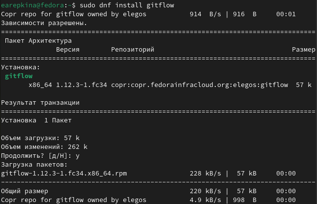

Установка

## Выполнение лабораторной работы.Установка Node.js

Устанавливаю Node.js (рис. [-@fig:002])

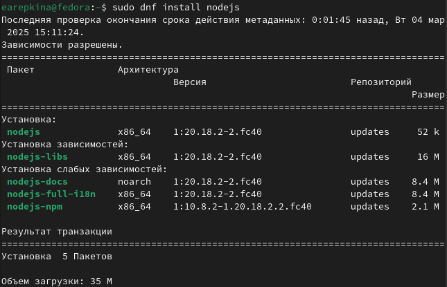

Установка

## Выполнение лабораторной работы.Установка Node.js

Продолжаю установку (рис. [-@fig:003])

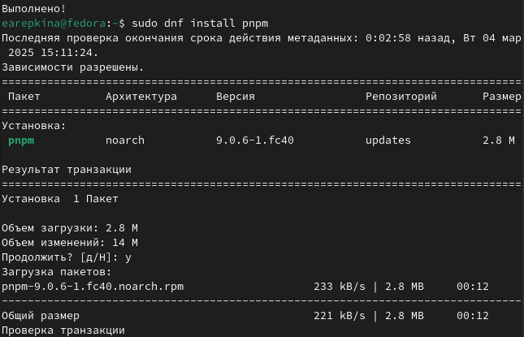

Установка

## Выполнение лабораторной работы.Настройка Node.js

Запускаю pnpm setup (рис. [-@fig:004])

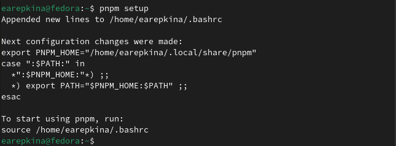

Запуск

## Выполнение лабораторной работы.Общепринятые коммиты commitizen

Данная программа используется для помощи в форматировании коммитов.рис. [-@fig:005])

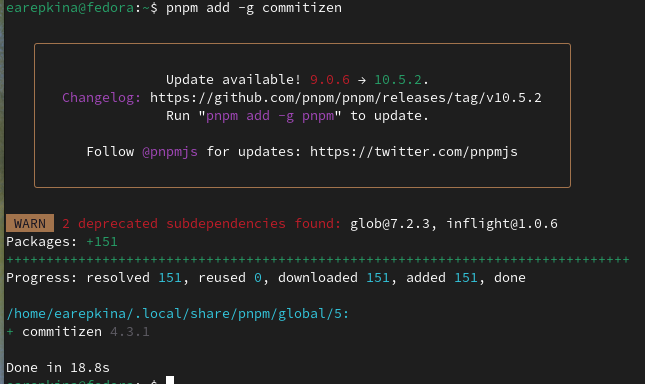

Выполнение команды

## Выполнение лабораторной работы.Общепринятые коммиты.standard-changelog

Данная программа используется для помощи в создании логов (рис. [-@fig:006])

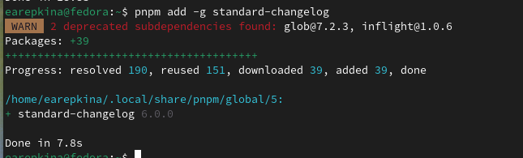

Выполнение команды

## Выполнение лабораторной работы.Практический сценарий использования git

Создаю репозиторий, делаю коммит и выкладываю на github (рис. [-@fig:007])

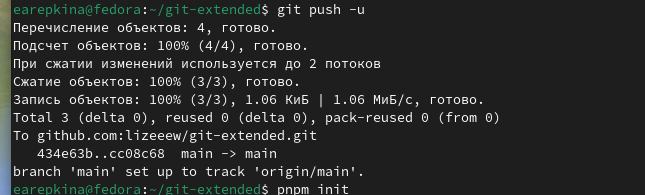

выкладываю на github

## Выполнение лабораторной работы.Создание репозитория git

Редактирую параметры пакета (рис. [-@fig:008])

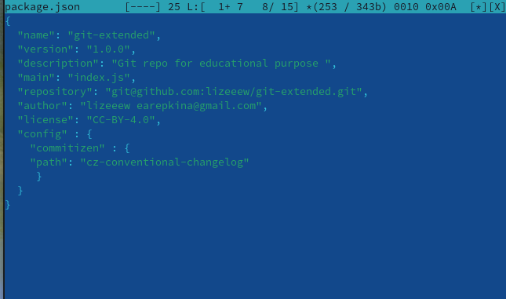

Редактирование

## Выполнение лабораторной работы.Конфигурация общепринятых коммитов

Добавляю новые файлы, выполняю коммит и отправляю на github (рис. [-@fig:009])

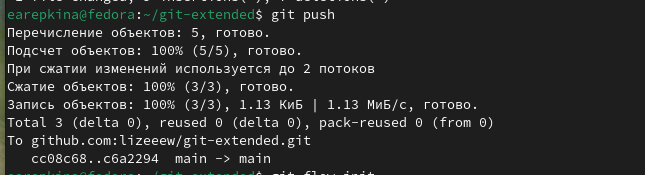

Отправка файлов

## Выполнение лабораторной работы.Конфигурация git-flow

Инициализирую git-flow (рис. [-@fig:010])

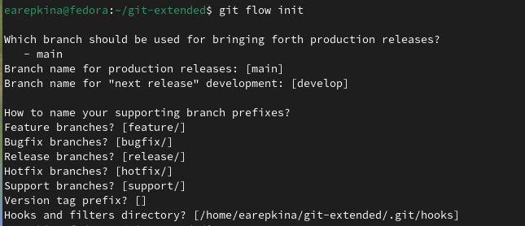

Инициализация

## Выполнение лабораторной работы.Конфигурация git-flow

Загружаю весь репозиторий в хранилище (рис. [-@fig:011])

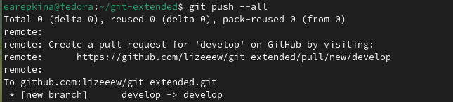

Загрузка

## Выполнение лабораторной работы.Конфигурация git-flow

Создаю релиз с версией 1.0.0 (рис. [-@fig:012])

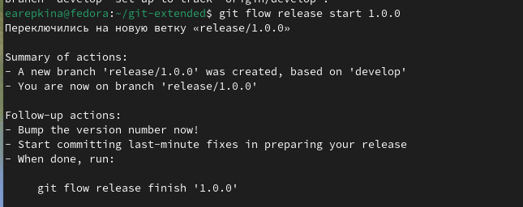

Создание релиза

## Выполнение лабораторной работы.Конфигурация git-flow

Создаю журнал изменений(рис. [-@fig:013])

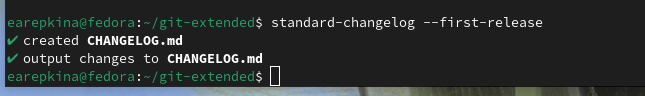

Создание журнала

## Выполнение лабораторной работы.Конфигурация git-flow

Добавляю журнал изменений в индекс (рис. [-@fig:014])

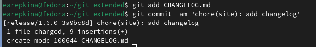

Добавление

## Выполнение лабораторной работы.Конфигурация git-flow

Заливаю релизную ветку в основную ветку (рис. [-@fig:015])

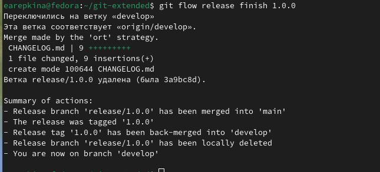

Залила релизную ветку

## Выполнение лабораторной работы.Конфигурация git-flow

отправляю данные на github (рис. [-@fig:016])

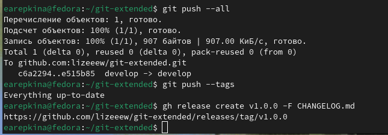

Отправка данных

## Выполнение лабораторной работы.Работа с репозиторием git

Создаю ветку для новой функциональности (рис. [-@fig:017])

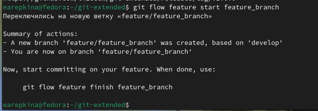

Создание ветки

## Выполнение лабораторной работы.Работа с репозиторием git

Далее, продолжаю работу c git как обычно. По окончании разработки новой функциональности следующим шагом объединяю ветку feature_branch c develop (рис. [-@fig:018])

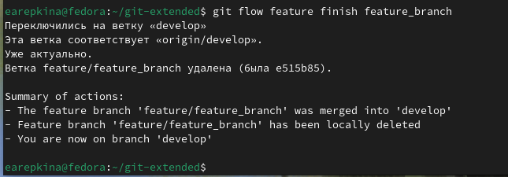

Объединение

## Выполнение лабораторной работы.Работа с репозиторием git

Создание релиза с версией 1.2.3 (рис. [-@fig:019])

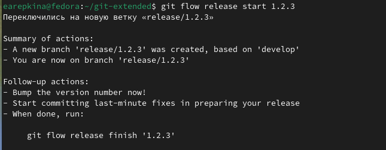

Создание релиза

## Выполнение лабораторной работы.Работа с репозиторием git

Обновляю номер версии в файле package.json. Устанавливаю её в 1.2.3. Создаю журнал изменений (рис. [-@fig:020])

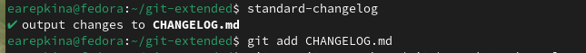

Создание журнала

## Выполнение лабораторной работы.Работа с репозиторием git

Добавляю журнал изменений в индекс и заливаю релизную ветку в основную ветку(рис. [-@fig:021])

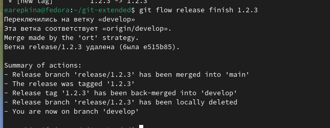

Заливаю релизную ветку

## Выполнение лабораторной работы.Работа с репозиторием git

Отправляю данные на github (рис. [-@fig:022])

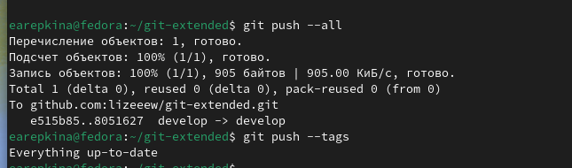

Отправка данных

## Выполнение лабораторной работы.Работа с репозиторием git

Создаю релиз на github с комментарием из журнала изменений (рис. [-@fig:023])

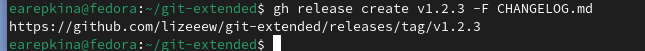

Создание релиза

## Выводы

В ходе выполнения работы я получила навыки правильной работы с репозиториями git.